# SEACAR Coral Analysis

Last compiled on 30 June, 2022

# Important Notes

All scripts and outputs can be found on the SEACAR GitHub repository:

https://github.com/FloridaSEACAR/SEACAR_Panzik

This script is based off of code originally wrtten by Katie May Laumann

# Libraries and Settings

Loads libraries used in the script. Loads the Segoe UI font for use in the figures. The inclusion of `scipen` option limits how frequently R defaults to scientific notation. Sets default settings for displaying warning and messages in created document, and sets figure dpi.

```r
library(knitr)
library(data.table)
library(dplyr)
library(lubridate)
library(ggplot2)
library(scales)
library(tidyr)
library(gridExtra)
library(tidyverse)
library(hrbrthemes)
library(nlme)
windowsFonts(`Segoe UI` = windowsFont('Segoe UI'))
options(scipen=999)
opts_chunk$set(warning=FALSE, message=FALSE, dpi=200)
```

# File Import

Imports percent cover files for each region for analysis.

```r
file_list <- list.files("data", pattern="Percent Cover", full=TRUE)

file_in <- file_list[grep("SE FL", file_list)]
CorSE <- fread(file_in, sep=",", header=TRUE, stringsAsFactors=FALSE,
               na.strings="")

file_in <- file_list[grep("DRY TORT", file_list)]
CorDRYTORTUGAS <- fread(file_in, sep=",", header=TRUE, stringsAsFactors=FALSE,
               na.strings="")

file_in <- file_list[grep("FLA KEYS", file_list)]
CorFLKEYS <- fread(file_in, sep=",", header=TRUE, stringsAsFactors=FALSE,
               na.strings="")
```

# Data Filtering

The processing and filtering that is done to the data is as follows for each region:

1. Removes non-coral species
2. `[PercentCover-SpeciesComposition_%]` column is renamed `perccov`
3. Removes data that contains NA values in percent cover
4. Create variable with full species name
5. Write data to file

Afterwards, the data from each region is combined into a single data frame.

```r
#We have more than corals here: see Groups 1 and 2.
#We only want corals, so filter by Group 2.
CorSE<-CorSE%>%filter(SpeciesGroup2=="Octocoral"|SpeciesGroup2=="Unspecifiedcoral")
#Current datasets do not include sampling method, which was requested. If sampling method is added to the dataset,
#seperate analyses by sampling method by first building a df for each method:
#CorSEMethod1<-CorSE%>%MethodRowName=="Method1"
#CorSEMethod2<-CorSE%>%MethodRowName=="Method2"
#then by running all of the following analyses for each method individually.
#This could be simplified by using lapply, if desired.

#rename columns to more easily work with them
colnames(CorSE)[colnames(CorSE) == "[PercentCover-SpeciesComposition_%]"] <- "Perccov"

#remove % cover NAs
CorSE <- CorSE[!is.na(CorSE$Perccov), ]

#convert to a numeric to be able to do math
CorSE$Perccov<-as.numeric(CorSE$Perccov)
CorSE <- CorSE[!is.na(CorSE$Perccov), ]

#combine genus and spp into one column in case you want to refine analyses to the species level.
CorSE$gensp<-paste(CorSE$GenusName, CorSE$SpeciesName, sep=" ")
CorSE<-CorSE%>%filter(gensp!="NA NA")

#Write to file
write.csv(CorSE,"data/CorSE.csv")

#We have more than corals here: see Groups 1 and 2.
#We only want corals, so filter by Group 2.
CorFLKEYS<-CorFLKEYS%>%filter(SpeciesGroup2=="Octocoral"|SpeciesGroup2=="Unspecifiedcoral")

#rename columns to more easily work with them
colnames(CorFLKEYS)[colnames(CorFLKEYS) == "[PercentCover-SpeciesComposition_%]"] <- "Perccov"

#remove % cover NAs
CorFLKEYS <- CorFLKEYS[!is.na(CorFLKEYS$Perccov), ]

#convert to a numeric to be able to do math
CorFLKEYS$Perccov<-as.numeric(CorFLKEYS$Perccov)
CorFLKEYS <- CorFLKEYS[!is.na(CorFLKEYS$Perccov), ]

#combine genus and spp into one column in case you want to refine analyses to the species level.
CorFLKEYS$gensp<-paste(CorFLKEYS$GenusName, CorFLKEYS$SpeciesName, sep=" ")
CorFLKEYS<-CorFLKEYS%>%filter(gensp!="NA NA")

#Write to file
write.csv(CorFLKEYS,"data/CorFLKeys.csv")

#We have more than corals here: see Groups 1 and 2.
#We only want corals, so filter by Group 2.
CorDRYTORTUGAS<-CorDRYTORTUGAS%>%filter(SpeciesGroup2=="Octocoral"|SpeciesGroup2=="Unspecifiedcoral")

#rename columns to more easily work with them
colnames(CorDRYTORTUGAS)[colnames(CorDRYTORTUGAS) == "[PercentCover-SpeciesComposition_%]"] <- "Perccov"

#remove % cover NAs
CorDRYTORTUGAS <- CorDRYTORTUGAS[!is.na(CorDRYTORTUGAS$Perccov), ]

#convert to a numeric to be able to do math
CorDRYTORTUGAS$Perccov<-as.numeric(CorDRYTORTUGAS$Perccov)
CorDRYTORTUGAS <- CorDRYTORTUGAS[!is.na(CorDRYTORTUGAS$Perccov), ]

#combine genus and spp into one column in case you want to refine analyses to the species level.
CorDRYTORTUGAS$gensp<-paste(CorDRYTORTUGAS$GenusName, CorDRYTORTUGAS$SpeciesName, sep=" ")
CorDRYTORTUGAS<-CorDRYTORTUGAS%>%filter(gensp!="NA NA")

#Write to file
write.csv(CorDRYTORTUGAS,"data/CorDryTortugas.csv")

#Combine data
CorSE <- CorSE %>%
  filter(ManagedAreaName=="Coral ECA")
CorFLKEYS <- CorFLKEYS %>%
  filter(ManagedAreaName=="Coral ECA"|ManagedAreaName=="Florida Keys NMS"|
           ManagedAreaName=="Coupon Bight")
CorDRYTORTUGAS <- CorDRYTORTUGAS %>%
  filter(ManagedAreaName=="Florida Keys NMS")

Cor <- rbind(CorSE,CorFLKEYS)
Cor <- rbind(Cor,CorDRYTORTUGAS)

#Remove duplicates
Cor <- Cor%>%filter(MADup!=2)
```

# Linera Mixed Effects Models

Performs a linear mixed effects (LME) model on each region between percent cover and year.

```r
coralperccov <- Cor%>%
  group_by(ManagedAreaName,Year)%>%
  summarise(mean(Perccov))

colnames(coralperccov) [3] <- "MeanPercCov"

# coralmodel<-lme(GenericRichness ~ MeanPercCov,
#                 random =~1|Year,
#                 na.action = na.omit,
#                 data = coralperccov)

CorSE_AnyCoral<-lme(Perccov ~ Year,
                    random =~1|ProgramLocationID,
                    na.action = na.omit,
                    data = CorSE)

#Here is where you examine your options for setting random variables and modifying your model.
#For example, there are only 2 programs sampling, but many program location IDs. For example,
#you may want to allow for different starting amounts of coral in each program location ID.
#To run multiple lmes at different levels, for example by SpeciesGroup2, do the following:
#Use the same type of model as above, but run it for each level (specified as i in the script)
#and print them to a list using lapply.

#In the following, we will allow for variation by program location ID.
CorSE_AnyCoral_lmelist2 <- lapply(unique(CorSE$Coral_Region),
                                  function(i)summary(
                                    lme(Perccov ~ Year,
                                        random =~1|ProgramLocationID,
                                        na.action = na.omit,
                                        data = subset(CorSE,
                                                      Coral_Region == i))))

#create and add a names list to the output, with each name corresponding to one
#unique taxon for the MA/in the model
names(CorSE_AnyCoral_lmelist2) <- unique(CorSE$Coral_Region)


##FL Keys
CorFLKEYS_AnyCoral<-lme(Perccov ~ Year,
                        random =~1|ProgramLocationID,
                        na.action = na.omit,
                        data = CorFLKEYS)

#Here is where you examine your options for setting random variables and modifying your model.
#For example, there are only 2 programs sampling, but many program location IDs. For example,
#you may want to allow for different starting amounts of coral in each program location ID.
#To run multiple lmes at different levels, for example by SpeciesGroup2, do the following:
#Use the same type of model as above, but run it for each level (specified as i in the script)
#and print them to a list using lapply.

#In the following, we will allow for variation by program location ID.
CorFLKEYS_AnyCoral_lmelist2<-lapply(unique(CorFLKEYS$Coral_Region),
                                    function(i)summary(lme(Perccov ~ Year,
                                                           random =~1|ProgramLocationID,
                                                           na.action = na.omit, data = subset(CorFLKEYS, Coral_Region == i))))

#create and add a names list to the output, with each name corresponding to one
#unique taxon for the MA/in the model
names(CorFLKEYS_AnyCoral_lmelist2) <- unique(CorFLKEYS$Coral_Region)

#Dry Tortugas
CorDRYTORTUGAS_AnyCoral<-lme(Perccov ~ Year,
                             random =~1|ProgramLocationID,
                             na.action = na.omit,
                             data = CorDRYTORTUGAS)

#Here is where you examine your options for setting random variables and modifying your model.
#For example, there are only 2 programs sampling, but many program location IDs. For example,
#you may want to allow for different starting amounts of coral in each program location ID.
#To run multiple lmes at different levels, for example by SpeciesGroup2, do the following:
#Use the same type of model as above, but run it for each level (specified as i in the script)
#and print them to a list using lapply.

#In the following, we will allow for variation by program location ID.
CorDRYTORTUGAS_AnyCoral_lmelist2<-lapply(unique(CorDRYTORTUGAS$Coral_Region),
                                         function(i)summary(
                                           lme(Perccov ~ Year,
                                               random =~1|ProgramLocationID,
                                               na.action = na.omit,
                                               data = subset(CorDRYTORTUGAS,
                                                             Coral_Region == i))))

#create and add a names list to the output, with each name corresponding to one
#unique taxon for the MA/in the model
names(CorDRYTORTUGAS_AnyCoral_lmelist2) <- unique(CorDRYTORTUGAS$Coral_Region)
```

# Appendix I: Plots

Plots are created for the LME results for each region and saved to a png file.

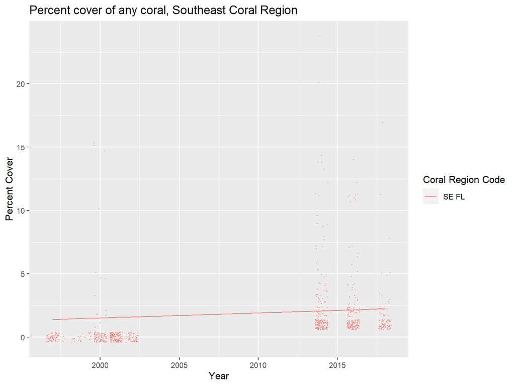

```r
##SE FL
preds <- do.call(rbind, lapply(names(CorSE_AnyCoral_lmelist2), function(i) {
  mod <- CorSE_AnyCoral_lmelist2[[i]]
  pred <- data.frame(Coral_Region = i, Year = mod$data$Year, pred = predict(mod, level = 0))
}))
#using that dataframe, plot, for each taxon, the observed values in each programlocationID
#for each year. Plot these as 'jittered' points.
#create a line that is the fitted model for each taxon, as well.
Plot_CorSE_AnyCoral<-ggplot() +
  geom_jitter(data = CorSE, aes(x = Year, y = Perccov, col = Coral_Region),size=0.1) +
  geom_line(data = preds, aes(x = Year, y = pred, group = Coral_Region, col = Coral_Region))
#label the plot and y axis (x was already labeled above)
Plot_CorSE_AnyCoral<-Plot_CorSE_AnyCoral + labs(y = "Percent Cover")
Plot_CorSE_AnyCoral<-Plot_CorSE_AnyCoral + labs(title = "Percent cover of any coral, Southeast Coral Region")
#color code your points and lines by taxon
Plot_CorSE_AnyCoral<-Plot_CorSE_AnyCoral + labs(colour = "Coral Region Code")
Plot_CorSE_AnyCoral
```

```r
#print to a png
png("output/CorallmePlot_AnyCoral_SERegion.png",
    width = 8,
    height = 4,
    units = "in",
    res = 200)
print(Plot_CorSE_AnyCoral)
dev.off()
```

png 2

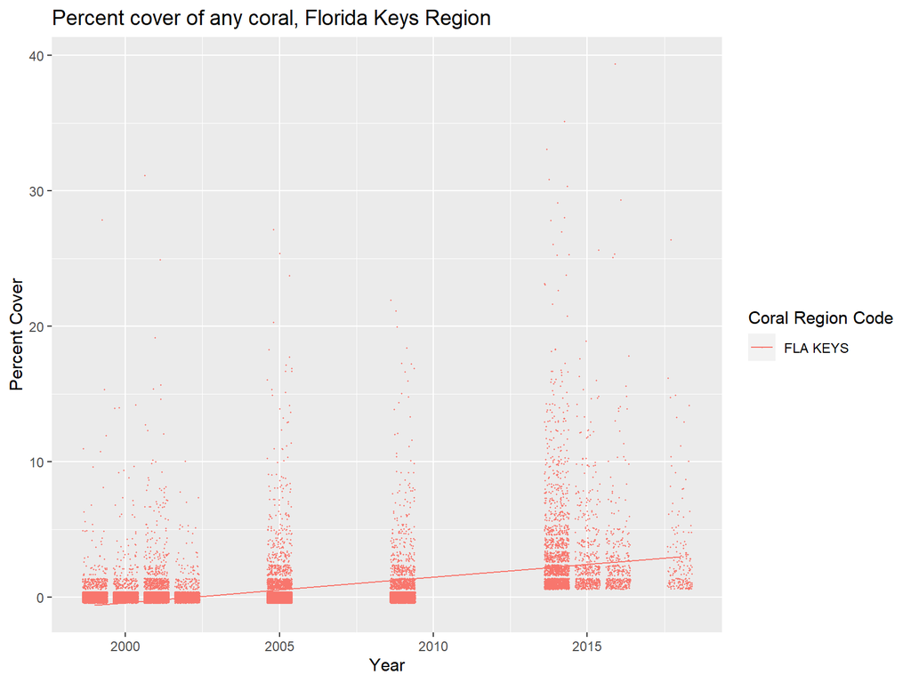

```r
##FL Keys
preds <- do.call(rbind, lapply(names(CorFLKEYS_AnyCoral_lmelist2), function(i) {
  mod <- CorFLKEYS_AnyCoral_lmelist2[[i]]
  pred <- data.frame(Coral_Region = i, Year = mod$data$Year, pred = predict(mod, level = 0))
}))
#using that dataframe, plot, for each taxon, the observed values in each programlocationID
#for each year. Plot these as 'jittered' points.
#create a line that is the fitted model for each taxon, as well.
Plot_CorFLKEYS_AnyCoral<-ggplot() +
  geom_jitter(data = CorFLKEYS, aes(x = Year, y = Perccov, col = Coral_Region),size=0.1) +
  geom_line(data = preds, aes(x = Year, y = pred, group = Coral_Region, col = Coral_Region))
#label the plot and y axis (x was already labeled above)
Plot_CorFLKEYS_AnyCoral<-Plot_CorFLKEYS_AnyCoral + labs(y = "Percent Cover")
Plot_CorFLKEYS_AnyCoral<-Plot_CorFLKEYS_AnyCoral + labs(title = "Percent cover of any coral, Florida Keys Region")
#color code your points and lines by taxon
Plot_CorFLKEYS_AnyCoral<-Plot_CorFLKEYS_AnyCoral + labs(colour = "Coral Region Code")
Plot_CorFLKEYS_AnyCoral
```

```r
#print to a png
png("output/CorallmePlot_AnyCoral_FLKEYSRegion.png",
    width = 8,
    height = 4,
    units = "in",
    res = 200)
print(Plot_CorFLKEYS_AnyCoral)
dev.off()
```

png 2

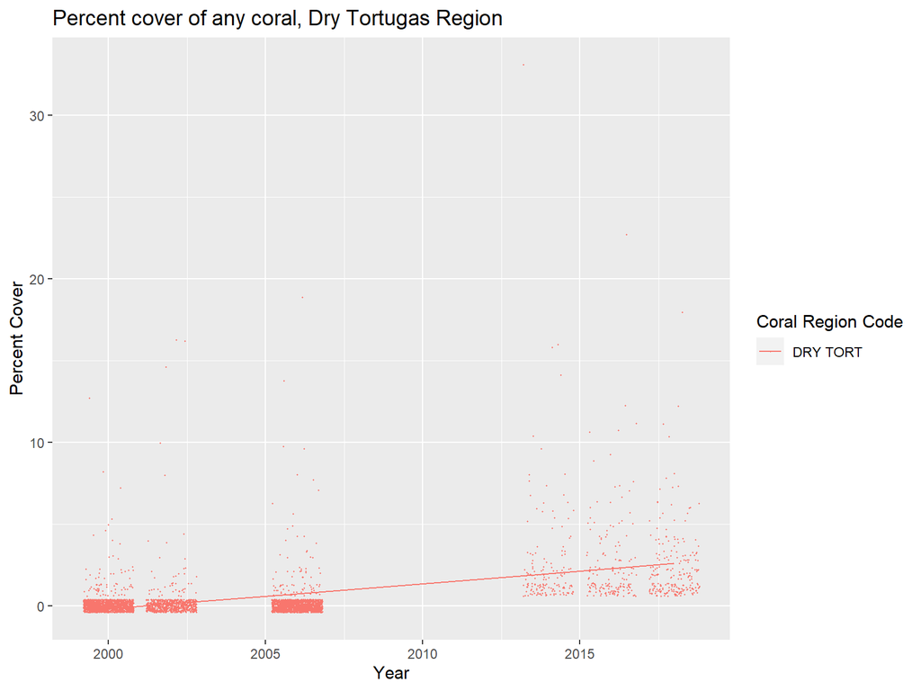

```r
##Dry Tortugas
preds <- do.call(rbind, lapply(names(CorDRYTORTUGAS_AnyCoral_lmelist2), function(i) {
  mod <- CorDRYTORTUGAS_AnyCoral_lmelist2[[i]]
  pred <- data.frame(Coral_Region = i, Year = mod$data$Year, pred = predict(mod, level = 0))
}))
#using that dataframe, plot, for each taxon, the observed values in each programlocationID
#for each year. Plot these as 'jittered' points.
#create a line that is the fitted model for each taxon, as well.
Plot_CorDRYTORTUGAS_AnyCoral<-ggplot() +
  geom_jitter(data = CorDRYTORTUGAS, aes(x = Year, y = Perccov, col = Coral_Region),size=0.1) +
  geom_line(data = preds, aes(x = Year, y = pred, group = Coral_Region, col = Coral_Region))
#label the plot and y axis (x was already labeled above)
Plot_CorDRYTORTUGAS_AnyCoral<-Plot_CorDRYTORTUGAS_AnyCoral + labs(y = "Percent Cover")
Plot_CorDRYTORTUGAS_AnyCoral<-Plot_CorDRYTORTUGAS_AnyCoral + labs(title = "Percent cover of any coral, Dry Tortugas Region")
#color code your points and lines by taxon
Plot_CorDRYTORTUGAS_AnyCoral<-Plot_CorDRYTORTUGAS_AnyCoral + labs(colour = "Coral Region Code")
Plot_CorDRYTORTUGAS_AnyCoral
```

```r
#print to a png
png("output/CorallmePlot_AnyCoral_DRYTORTUGASRegion.png",
    width = 8,
    height = 4,
    units = "in",
    res = 200)
print(Plot_CorDRYTORTUGAS_AnyCoral)
dev.off()
```

png 2